# klavinde_final_exam

# Cleaning Data is a large portion of initial coding.

```r
arpack <- c("arules","arulesViz")
# install.packages(arpack) install if needed
library(arules)
library(arulesViz)
library(tidyverse)
library(cluster)
library(caret)
fuel_data.df <- read.csv("fuel_receipts_costs.csv")
summary(fuel_data.df)
```

```
##      rowid         plant_id_eia   plant_id_eia_label report_date
##  Min.   :     1   Min.   :    3   Length:663572      Length:663572
##  1st Qu.:165894   1st Qu.: 2720   Class :character   Class :character
##  Median :331787   Median : 6178   Mode  :character   Mode  :character
##  Mean   :331787   Mean   :18634
##  3rd Qu.:497679   3rd Qu.:50835
##  Max.   :663572   Max.   :65978
##
##  contract_type_code contract_type_code_label contract_expiration_date
##  Length:663572      Length:663572            Length:663572
##  Class :character   Class :character         Class :character
##  Mode  :character   Mode  :character         Mode  :character
##
##
##
##
##  energy_source_code energy_source_code_label fuel_type_code_pudl
##  Length:663572      Length:663572            Length:663572
##  Class :character   Class :character         Class :character
##  Mode  :character   Mode  :character         Mode  :character
##
##
##
##
##  fuel_group_code     mine_id_pudl    mine_id_pudl_label supplier_name
##  Length:663572      Min.   :   0     Min.   :   0       Length:663572
##  Class :character   1st Qu.:  43     1st Qu.:  43       Class :character
##  Mode  :character   Median :1052     Median :1052       Mode  :character
##                     Mean   :1642     Mean   :1642
##                     3rd Qu.:3122     3rd Qu.:3122
##                     Max.   :4806     Max.   :4806
##                     NA's   :432955   NA's   :432955
##  fuel_received_units fuel_mmbtu_per_unit sulfur_content_pct ash_content_pct
##  Min.   :       1    Min.   :   0.000    Min.   : 0.0000    Min.   : 0.000
##  1st Qu.:    3880    1st Qu.:   1.026    1st Qu.: 0.0000    1st Qu.: 0.000
##  Median :   22585    Median :   1.060    Median : 0.0000    Median : 0.000
##  Mean   :  255079    Mean   :   8.636    Mean   : 0.5022    Mean   : 3.503
##  3rd Qu.:  112321    3rd Qu.:  17.754    3rd Qu.: 0.4300    3rd Qu.: 5.600
##  Max.   :48159765    Max.   :1049.000    Max.   :21.2400    Max.   :72.200
##
```

[output cut: 25 more lines]

```
##  Length:663572                           Min.   :  0.0
##  Class :character                        1st Qu.:  6.7
##  Mode  :character                        Median : 12.2
##                                          Mean   : 15.9
##                                          3rd Qu.: 26.9
##                                          Max.   :247.0
##                                          NA's   :557501
##  chlorine_content_ppm data_maturity      data_maturity_label
##  Min.   :   0.0       Length:663572      Length:663572
##  1st Qu.:   0.0       Class :character   Class :character
##  Median :   0.0       Mode  :character   Mode  :character
##  Mean   :  57.9
##  3rd Qu.:   0.0
##  Max.   :3747.0
##  NA's   :557501
```

```r
row.names(fuel_data.df) <- fuel_data.df[,1]
fuel_numeric<-fuel_data.df%>%column_to_rownames(var = "rowid")
summary(fuel_numeric)
```

```
##   plant_id_eia   plant_id_eia_label report_date        contract_type_code
##  Min.   :    3   Length:663572      Length:663572      Length:663572
##  1st Qu.: 2720   Class :character   Class :character   Class :character
##  Median : 6178   Mode  :character   Mode  :character   Mode  :character
##  Mean   :18634
##  3rd Qu.:50835
##  Max.   :65978
##
##  contract_type_code_label contract_expiration_date energy_source_code
##  Length:663572            Length:663572            Length:663572
##  Class :character         Class :character         Class :character
##  Mode  :character         Mode  :character         Mode  :character
##
##
##
##
##  energy_source_code_label fuel_type_code_pudl fuel_group_code
##  Length:663572            Length:663572       Length:663572
##  Class :character         Class :character    Class :character
##  Mode  :character         Mode  :character    Mode  :character
##
##
##
##
##   mine_id_pudl    mine_id_pudl_label supplier_name      fuel_received_units
##  Min.   :   0     Min.   :   0       Length:663572      Min.   :       1
##  1st Qu.:  43     1st Qu.:  43       Class :character   1st Qu.:    3880
##  Median :1052     Median :1052       Mode  :character   Median :   22585
##  Mean   :1642     Mean   :1642                          Mean   :  255079
##  3rd Qu.:3122     3rd Qu.:3122                          3rd Qu.:  112321
##  Max.   :4806     Max.   :4806                          Max.   :48159765
##  NA's   :432955   NA's   :432955
##  fuel_mmbtu_per_unit sulfur_content_pct ash_content_pct  mercury_content_ppm
##  Min.   :   0.000    Min.   : 0.0000    Min.   : 0.000   Min.   :0.00
##  1st Qu.:   1.026    1st Qu.: 0.0000    1st Qu.: 0.000   1st Qu.:0.00
##  Median :   1.060    Median : 0.0000    Median : 0.000   Median :0.00
##  Mean   :   8.636    Mean   : 0.5022    Mean   : 3.503   Mean   :0.01
##  3rd Qu.:  17.754    3rd Qu.: 0.4300    3rd Qu.: 5.600   3rd Qu.:0.00
##  Max.   :1049.000    Max.   :21.2400    Max.   :72.200   Max.   :6.25
##                                                          NA's   :289482
```

[output cut: 25 more lines]

```
##  Length:663572                           Min.   :  0.0
##  Class :character                        1st Qu.:  6.7
##  Mode  :character                        Median : 12.2
##                                          Mean   : 15.9
##                                          3rd Qu.: 26.9
##                                          Max.   :247.0
##                                          NA's   :557501
##  chlorine_content_ppm data_maturity      data_maturity_label
##  Min.   :   0.0       Length:663572      Length:663572
##  1st Qu.:   0.0       Class :character   Class :character
##  Median :   0.0       Mode  :character   Mode  :character
##  Mean   :  57.9
##  3rd Qu.:   0.0
##  Max.   :3747.0
##  NA's   :557501
```

## There are many categorical data points and some columns have a large amount of “NA” data points.

```r
library(tidyverse)
library(cluster)
summary(fuel_data.df)
```

```
##      rowid         plant_id_eia   plant_id_eia_label report_date
##  Min.   :     1   Min.   :    3   Length:663572      Length:663572
##  1st Qu.:165894   1st Qu.: 2720   Class :character   Class :character
##  Median :331787   Median : 6178   Mode  :character   Mode  :character
##  Mean   :331787   Mean   :18634
##  3rd Qu.:497679   3rd Qu.:50835
##  Max.   :663572   Max.   :65978
##
##  contract_type_code contract_type_code_label contract_expiration_date
##  Length:663572      Length:663572            Length:663572
##  Class :character   Class :character         Class :character
##  Mode  :character   Mode  :character         Mode  :character
##
##
##
##
##  energy_source_code energy_source_code_label fuel_type_code_pudl
##  Length:663572      Length:663572            Length:663572
##  Class :character   Class :character         Class :character
##  Mode  :character   Mode  :character         Mode  :character
##
##
##
##
##  fuel_group_code     mine_id_pudl    mine_id_pudl_label supplier_name
##  Length:663572      Min.   :   0     Min.   :   0       Length:663572
##  Class :character   1st Qu.:  43     1st Qu.:  43       Class :character
##  Mode  :character   Median :1052     Median :1052       Mode  :character
##                     Mean   :1642     Mean   :1642
##                     3rd Qu.:3122     3rd Qu.:3122
##                     Max.   :4806     Max.   :4806
##                     NA's   :432955   NA's   :432955
##  fuel_received_units fuel_mmbtu_per_unit sulfur_content_pct ash_content_pct
##  Min.   :       1    Min.   :   0.000    Min.   : 0.0000    Min.   : 0.000
##  1st Qu.:    3880    1st Qu.:   1.026    1st Qu.: 0.0000    1st Qu.: 0.000
##  Median :   22585    Median :   1.060    Median : 0.0000    Median : 0.000
##  Mean   :  255079    Mean   :   8.636    Mean   : 0.5022    Mean   : 3.503
##  3rd Qu.:  112321    3rd Qu.:  17.754    3rd Qu.: 0.4300    3rd Qu.: 5.600
##  Max.   :48159765    Max.   :1049.000    Max.   :21.2400    Max.   :72.200
##
```

[output cut: 25 more lines]

```
##  Length:663572                           Min.   :  0.0
##  Class :character                        1st Qu.:  6.7
##  Mode  :character                        Median : 12.2
##                                          Mean   : 15.9
##                                          3rd Qu.: 26.9
##                                          Max.   :247.0
##                                          NA's   :557501
##  chlorine_content_ppm data_maturity      data_maturity_label
##  Min.   :   0.0       Length:663572      Length:663572
##  1st Qu.:   0.0       Class :character   Class :character
##  Median :   0.0       Mode  :character   Mode  :character
##  Mean   :  57.9
##  3rd Qu.:   0.0
##  Max.   :3747.0
##  NA's   :557501
```

```r
colSums(is.na(fuel_data.df))
```

```
##                                    rowid
##                                        0
##                             plant_id_eia
##                                        0
##                       plant_id_eia_label
##                                        0
##                              report_date
##                                        0
##                       contract_type_code
##                                        0
##                 contract_type_code_label
##                                        0
##                 contract_expiration_date
##                                        0
##                       energy_source_code
##                                        0
##                 energy_source_code_label
##                                        0
##                      fuel_type_code_pudl
##                                        0
##                          fuel_group_code
##                                        0
##                             mine_id_pudl
##                                   432955
##                       mine_id_pudl_label
##                                   432955
##                            supplier_name
##                                        0
##                      fuel_received_units
##                                        0
##                      fuel_mmbtu_per_unit
##                                        0
##                       sulfur_content_pct
##                                        0
##                          ash_content_pct
##                                        0
##                      mercury_content_ppm
##                                   289482
##                      fuel_cost_per_mmbtu
##                                   214941
##         primary_transportation_mode_code
##                                        0
##   primary_transportation_mode_code_label
##                                        0
##       secondary_transportation_mode_code
##                                        0
## secondary_transportation_mode_code_label
##                                        0
##               natural_gas_transport_code
##                                        0
##  natural_gas_delivery_contract_type_code
##                                        0
##                     moisture_content_pct
##                                   557501
##                     chlorine_content_ppm
##                                   557501
##                            data_maturity
##                                        0
##                      data_maturity_label
##                                        0
```

## Fuel Type converted to numerical data to include in clustering

```r
fuel_numeric ["fuel_group_code"][fuel_numeric ["fuel_group_code"] == ''] <- NA
fuel_numeric <-fuel_numeric [-which(is.na(fuel_numeric$fuel_group_code)), ]
summary(fuel_numeric)
```

```
##   plant_id_eia   plant_id_eia_label report_date        contract_type_code
##  Min.   :    3   Length:663571      Length:663571      Length:663571
##  1st Qu.: 2720   Class :character   Class :character   Class :character
##  Median : 6178   Mode  :character   Mode  :character   Mode  :character
##  Mean   :18634
##  3rd Qu.:50835
##  Max.   :65978
##
##  contract_type_code_label contract_expiration_date energy_source_code
##  Length:663571            Length:663571            Length:663571
##  Class :character         Class :character         Class :character
##  Mode  :character         Mode  :character         Mode  :character
##
##
##
##
##  energy_source_code_label fuel_type_code_pudl fuel_group_code
##  Length:663571            Length:663571       Length:663571
##  Class :character         Class :character    Class :character
##  Mode  :character         Mode  :character    Mode  :character
##
##
##
##
##   mine_id_pudl    mine_id_pudl_label supplier_name      fuel_received_units
##  Min.   :   0     Min.   :   0       Length:663571      Min.   :       1
##  1st Qu.:  43     1st Qu.:  43       Class :character   1st Qu.:    3880
##  Median :1052     Median :1052       Mode  :character   Median :   22585
##  Mean   :1642     Mean   :1642                          Mean   :  255080
##  3rd Qu.:3122     3rd Qu.:3122                          3rd Qu.:  112321
##  Max.   :4806     Max.   :4806                          Max.   :48159765
##  NA's   :432954   NA's   :432954
##  fuel_mmbtu_per_unit sulfur_content_pct ash_content_pct  mercury_content_ppm
##  Min.   :   0.000    Min.   : 0.0000    Min.   : 0.000   Min.   :0.00
##  1st Qu.:   1.026    1st Qu.: 0.0000    1st Qu.: 0.000   1st Qu.:0.00
##  Median :   1.060    Median : 0.0000    Median : 0.000   Median :0.00
##  Mean   :   8.636    Mean   : 0.5022    Mean   : 3.503   Mean   :0.01
##  3rd Qu.:  17.754    3rd Qu.: 0.4300    3rd Qu.: 5.600   3rd Qu.:0.00
##  Max.   :1049.000    Max.   :21.2400    Max.   :72.200   Max.   :6.25
##                                                          NA's   :289482
```

[output cut: 25 more lines]

```
##  Length:663571                           Min.   :  0.0
##  Class :character                        1st Qu.:  6.7
##  Mode  :character                        Median : 12.2
##                                          Mean   : 15.9
##                                          3rd Qu.: 26.9
##                                          Max.   :247.0
##                                          NA's   :557500
##  chlorine_content_ppm data_maturity      data_maturity_label
##  Min.   :   0.0       Length:663571      Length:663571
##  1st Qu.:   0.0       Class :character   Class :character
##  Median :   0.0       Mode  :character   Mode  :character
##  Mean   :  57.9
##  3rd Qu.:   0.0
##  Max.   :3747.0
##  NA's   :557500
```

```r
fuel_numeric$fuel_group_code <- as.numeric(as.factor(fuel_numeric$fuel_group_code))
summary(fuel_numeric)
```

```
##   plant_id_eia   plant_id_eia_label report_date        contract_type_code
##  Min.   :    3   Length:663571      Length:663571      Length:663571
##  1st Qu.: 2720   Class :character   Class :character   Class :character
##  Median : 6178   Mode  :character   Mode  :character   Mode  :character
##  Mean   :18634
##  3rd Qu.:50835
##  Max.   :65978
##
##  contract_type_code_label contract_expiration_date energy_source_code
##  Length:663571            Length:663571            Length:663571
##  Class :character         Class :character         Class :character
##  Mode  :character         Mode  :character         Mode  :character
##
##
##
##
##  energy_source_code_label fuel_type_code_pudl fuel_group_code  mine_id_pudl
##  Length:663571            Length:663571       Min.   :1.000   Min.   :   0
##  Class :character         Class :character    1st Qu.:1.000   1st Qu.:  43
##  Mode  :character         Mode  :character    Median :2.000   Median :1052
##                                               Mean   :1.837   Mean   :1642
##                                               3rd Qu.:2.000   3rd Qu.:3122
##                                               Max.   :5.000   Max.   :4806
##                                                               NA's   :432954
##  mine_id_pudl_label supplier_name      fuel_received_units fuel_mmbtu_per_unit
##  Min.   :   0       Length:663571      Min.   :       1    Min.   :   0.000
##  1st Qu.:  43       Class :character   1st Qu.:    3880    1st Qu.:   1.026
##  Median :1052       Mode  :character   Median :   22585    Median :   1.060
##  Mean   :1642                          Mean   :  255080    Mean   :   8.636
##  3rd Qu.:3122                          3rd Qu.:  112321    3rd Qu.:  17.754
##  Max.   :4806                          Max.   :48159765    Max.   :1049.000
##  NA's   :432954
##  sulfur_content_pct ash_content_pct  mercury_content_ppm fuel_cost_per_mmbtu
##  Min.   : 0.0000    Min.   : 0.000   Min.   :0.00        Min.   :   -71.9
##  1st Qu.: 0.0000    1st Qu.: 0.000   1st Qu.:0.00        1st Qu.:     2.3
##  Median : 0.0000    Median : 0.000   Median :0.00        Median :     3.3
##  Mean   : 0.5022    Mean   : 3.503   Mean   :0.01        Mean   :    14.0
##  3rd Qu.: 0.4300    3rd Qu.: 5.600   3rd Qu.:0.00        3rd Qu.:     5.1
##  Max.   :21.2400    Max.   :72.200   Max.   :6.25        Max.   :562572.2
##                                      NA's   :289482      NA's   :214941
```

[output cut: 25 more lines]

```
##  Min.   :  0.0        Min.   :   0.0       Length:663571
##  1st Qu.:  6.7        1st Qu.:   0.0       Class :character
##  Median : 12.2        Median :   0.0       Mode  :character
##  Mean   : 15.9        Mean   :  57.9
##  3rd Qu.: 26.9        3rd Qu.:   0.0
##  Max.   :247.0        Max.   :3747.0
##  NA's   :557500       NA's   :557500
##  data_maturity_label
##  Length:663571
##  Class :character
##  Mode  :character
##
##
##
##
```

## Fuel Types 1. Coal | 2. Natural Gas | 3. Other Gas | 4. Petroleum | 5. Petroleum Coke

### Alphabetized

```r
fuel_numeric <- fuel_numeric[,c(10,14,15,16,17,18,19)]
summary(fuel_numeric)
```

```
##  fuel_group_code fuel_received_units fuel_mmbtu_per_unit sulfur_content_pct
##  Min.   :1.000   Min.   :       1    Min.   :   0.000    Min.   : 0.0000
##  1st Qu.:1.000   1st Qu.:    3880    1st Qu.:   1.026    1st Qu.: 0.0000
##  Median :2.000   Median :   22585    Median :   1.060    Median : 0.0000
##  Mean   :1.837   Mean   :  255080    Mean   :   8.636    Mean   : 0.5022
##  3rd Qu.:2.000   3rd Qu.:  112321    3rd Qu.:  17.754    3rd Qu.: 0.4300
##  Max.   :5.000   Max.   :48159765    Max.   :1049.000    Max.   :21.2400
##
##  ash_content_pct  mercury_content_ppm fuel_cost_per_mmbtu
##  Min.   : 0.000   Min.   :0.00        Min.   :   -71.9
##  1st Qu.: 0.000   1st Qu.:0.00        1st Qu.:     2.3
##  Median : 0.000   Median :0.00        Median :     3.3
##  Mean   : 3.503   Mean   :0.01        Mean   :    14.0
##  3rd Qu.: 5.600   3rd Qu.:0.00        3rd Qu.:     5.1
##  Max.   :72.200   Max.   :6.25        Max.   :562572.2
##                   NA's   :289482      NA's   :214941
```

## Data Cleaned! To numerical and without N/A data points.

```r
fuel_numeric<- na.omit(fuel_numeric) %>% select_if(is.numeric)
summary(fuel_numeric)
```

```
##  fuel_group_code fuel_received_units fuel_mmbtu_per_unit sulfur_content_pct
##  Min.   :1.000   Min.   :       1    Min.   :   0.000    Min.   :0.0000
##  1st Qu.:1.000   1st Qu.:    4224    1st Qu.:   1.027    1st Qu.:0.0000
##  Median :2.000   Median :   24714    Median :   1.049    Median :0.0000
##  Mean   :1.863   Mean   :  225948    Mean   :   7.374    Mean   :0.3956
##  3rd Qu.:2.000   3rd Qu.:  106464    3rd Qu.:  17.302    3rd Qu.:0.2300
##  Max.   :5.000   Max.   :15646257    Max.   :1049.000    Max.   :8.8300
##  ash_content_pct  mercury_content_ppm fuel_cost_per_mmbtu
##  Min.   : 0.000   Min.   :0.000000    Min.   :   -71.9
##  1st Qu.: 0.000   1st Qu.:0.000000    1st Qu.:     2.2
##  Median : 0.000   Median :0.000000    Median :     3.1
##  Mean   : 2.367   Mean   :0.004519    Mean   :    18.6
##  3rd Qu.: 4.700   3rd Qu.:0.000000    3rd Qu.:     4.7
##  Max.   :61.600   Max.   :6.250000    Max.   :562572.2
```

# Final Cleaning

### Sampled data down to ~3000 observations using partitioning.

```r
library(caret)
set.seed(4381)
Fuel_Index = createDataPartition(fuel_numeric$fuel_mmbtu_per_unit, p=0.988, list = FALSE)
Fuel_Valid = fuel_numeric[Fuel_Index, ]
Fuel_Train = fuel_numeric[-Fuel_Index, ]
head(Fuel_Train)
```

|  | fuel_group_code | fuel_received_units | fuel_mmbtu_per_unit | sulfur_content_pct | ash_content_pct | mercury_content_ppm | fuel_cost_per_mmbtu |
| --- | --- | --- | --- | --- | --- | --- | --- |
| 240072 | 1 | 12719 | 16.830 | 0.34 | 5.1 | 0.1 | 2.935 |
| 241132 | 2 | 281230 | 1.020 | 0.00 | 0.0 | 0.0 | 3.247 |
| 241154 | 2 | 1940 | 1.020 | 0.00 | 0.0 | 0.0 | 2.713 |
| 241208 | 2 | 326 | 1.021 | 0.00 | 0.0 | 0.0 | 3.234 |
| 241433 | 2 | 4840 | 1.036 | 0.00 | 0.0 | 0.0 | 3.626 |
| 241468 | 2 | 6418 | 1.012 | 0.00 | 0.0 | 0.0 | 2.705 |

```r
scaled_fuel_data <- as.data.frame(scale(Fuel_Train))
fuel_euclidean <- dist(scaled_fuel_data, method = "euclidean")
hc <- hclust(fuel_euclidean, method="ward.D2")
```

```r
methods <- c( "average", "single", "complete", "ward")
names(methods) <- c( "average", "single", "complete", "ward")
ac <- function(x) {
  agnes(scaled_fuel_data, metric = "euclidean", method = x)$ac
}
```

## Ward Method is preferred for this data

```r
map_dbl(methods, ac)
```

```
##   average    single  complete      ward
## 0.9981471 0.9977521 0.9985812 0.9994610
```

#### This next step takes the most CPU

```r
hc_wards <- agnes(scaled_fuel_data, method = "ward", metric = "euclidean")
```

```r
hc_wards
```

```
## Call:     agnes(x = scaled_fuel_data, metric = "euclidean", method = "ward")
## Agglomerative coefficient:  0.999461
## Order of objects:
##    [1] 240072 261529 263759 327314 316131 336646 265177 267060 267082 322839
##   [11] 330111 341302 241867 624818 260386 248407 254766 271460 245421 509024
##   [21] 250448 270406 251850 398404 247428 322559 342953 325968 386082 336049
##   [31] 482781 539558 590195 442244 350286 359969 416684 472436 420338 505670
##   [41] 487294 433252 466893 645398 540301 575604 581600 322354 453659 521878
##   [51] 551930 385239 419942 441430 388237 416874 401134 496145 331548 466824
##   [61] 537320 478857 527996 543063 387436 526901 397260 584599 638976 399024
##   [71] 474876 533202 407723 594840 543764 453728 434336 627645 434840 442392
##   [81] 496248 388975 431176 405457 452066 580491 659445 492720 412999 517548
##   [91] 658200 507548 542152 493499 583906 594184 414202 610061 632382 654232
##  [101] 521656 391307 572610 444122 393670 653467 661556 458724 459454 632338
##  [111] 524910 595867 485853 469810 475501 424004 434669 492217 649199 651180
```

[output cut: 309 more lines]

```r
library(factoextra)
hc_wards_cut <- cutree(hc_wards, k=7)
table(hc_wards_cut)
```

```
## hc_wards_cut
##    1    2    3    4    5    6    7
##  164 1839  255  105  514  257    2
```

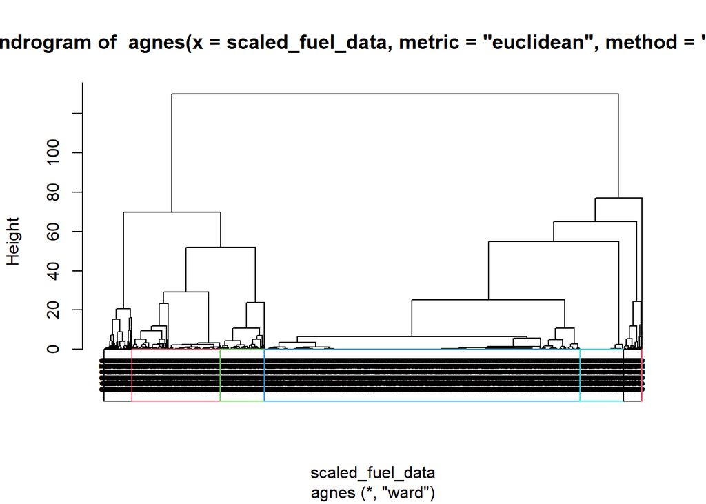

```r
pltree(hc_wards, cex = 0.6, hang = -1)
rect.hclust(hc_wards, k = 7, border = 1:5)
```

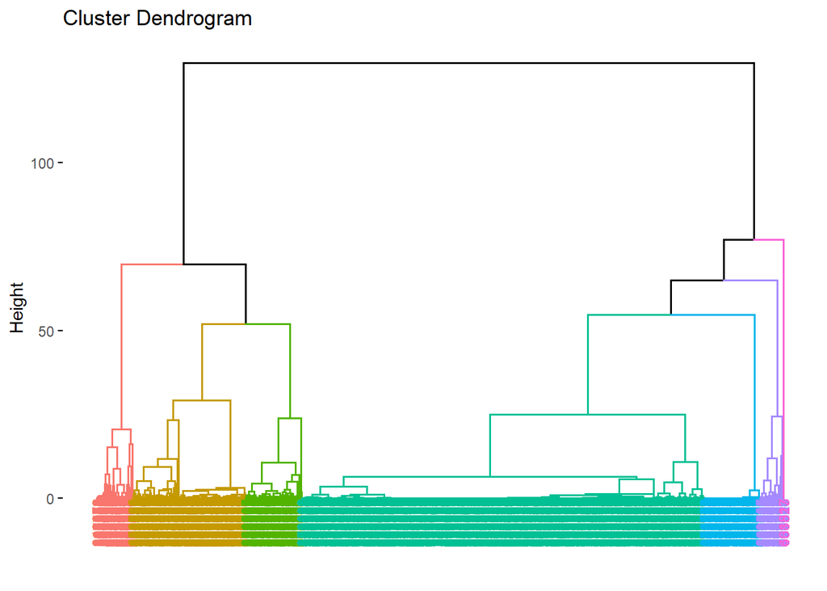

```r
fviz_dend(hc_wards, cex = 0.6, k = 7)
```

## First Division: Right is Natural Gas, left is Coal, Petroleum, and Petroleum Coke.

```r
library(caret)
library(factoextra)
fuel_data_clustered <- mutate(scaled_fuel_data, cluster = hc_wards_cut)
set.seed(2457)
index <- createDataPartition(fuel_data_clustered$cluster, p = 0.7, list = FALSE)
part_A <- fuel_data_clustered[index,]
part_B <- fuel_data_clustered[-index,]
```

```r
hc_wards_A <- agnes(part_A[,1:7], method = "ward", metric = "euclidean")
```

```r
hc_cut_A <- cutree(hc_wards_A, k=7)
part_A <- mutate(part_A, cluster = hc_cut_A)
part_A_centroids <- aggregate(part_A[,1:7], by=list(part_A$cluster), mean)
colnames(part_A_centroids)[1] <- "cluster"
cluster_prediction_B <- data.frame(data=seq(1,nrow(part_B)), Partition_B_cluster=rep(0,nrow(part_B)))
euclidean <- function(a, b) sqrt(sum((a - b)^2))
```

```r
for (i in 1:nrow(part_B)) {
  distances <- apply(part_A_centroids[, -1], 1, function(x) euclidean(x, part_B[i,1:7]))
  cluster_prediction_B$Partition_B_cluster[i] <- which.min(distances)
}
```

```r
cluster_prediction_B <- cluster_prediction_B %>% mutate(original_clusters = part_B$cluster)
```

```r
table(cluster_prediction_B$Partition_B_cluster, cluster_prediction_B$original_clusters, dnn = c("New Cluster", "Old Cluster"))
```

```
##            Old Cluster
## New Cluster   1   2   3   4   5   6
##           1   0 557   0   0   0   0
##           2   0   0  82   0   0   0
##           3   0   2   0  26   0   0
##           4  36   0   0   0   0   0
##           5   2   0   0   0 156   0
##           6   3   0   0   0   7  68
```

# HEAT MAP of cleaned, normalized data.

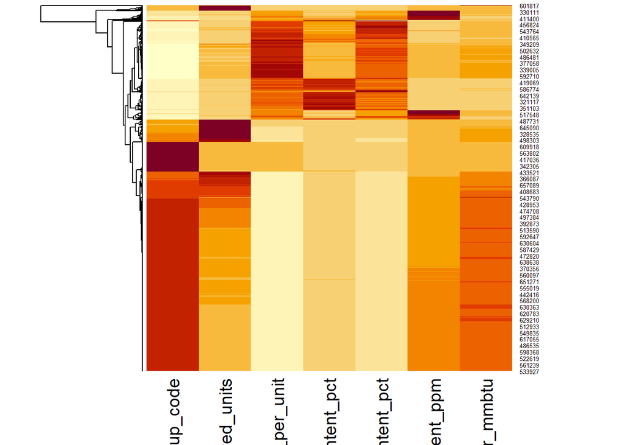

```r
heatmap(as.matrix(scaled_fuel_data), Colv = NA, hclustfun = hclust)
```

# This portion is the most useful for reports.

```r
cluster <- hc_wards_cut
centers <- aggregate( . ~ cluster, data = Fuel_Train, FUN = mean)
centers
```

| cluster | fuel_group_code | fuel_received_units | fuel_mmbtu_per_unit | sulfur_content_pct | ash_content_pct | mercury_content_ppm | fuel_cost_per_mmbtu |
| --- | --- | --- | --- | --- | --- | --- | --- |
| 1 | 1.000000 | 61745.305 | 19.386232 | 0.8177439 | 6.857927 | 0.0842682927 | 2.307488 |
| 2 | 2.000000 | 158347.034 | 1.035727 | 0.0000000 | 0.000000 | 0.0000000000 | 7.494966 |
| 3 | 4.000000 | 7615.349 | 5.819024 | 0.0225098 | 0.000000 | 0.0000000000 | 16.775204 |
| 4 | 2.000000 | 3113120.657 | 1.029933 | 0.0000000 | 0.000000 | 0.0000000000 | 3.620800 |
| 5 | 1.000000 | 61212.428 | 19.852130 | 0.5662646 | 7.741245 | 0.0000155642 | 2.454292 |
| 6 | 1.124514 | 43844.903 | 23.738946 | 3.1192218 | 8.773385 | 0.0000000000 | 2.376171 |
| 7 | 2.000000 | 460.500 | 1.070500 | 0.0000000 | 0.000000 | 0.0000000000 | 31052.784500 |

# Cluster 1: Dirtier Coal

### Predominate Fuel Type: Coal

### Quantity (1.8 % of data)

### Thermal Content (Very High)

### Sulfur Content: Moderate

### Ash Content: High

### Mercury Content: High

### Fuel Cost Per thermal units $2.31

# Cluster 2: Slightly Better Natural Gas

### Predominate Fuel Type: Natural Gas

### Quantity (4.59 % of data)

### Sulfur Content: None/Scant

### Ash Content: None/Scant

### Mercury Content: None/Scant

### Fuel Cost Per thermal units $7.49

# Cluster 3: Petroleum

### Predominate Fuel Type: Petroleum

### Quantity (0.2 % of data)

### Thermal Content (Moderate)

### Sulfur Content: Low

### Ash Content: None/Scant

### Mercury Content: None/Scant

### Fuel Cost Per thermal units $16.78

# Cluster 4: Standard Natural Gas

### Predominate Fuel Type: Natural Gas

### Quantity (90.33 % of data)

### Sulfur Content: None/Scant

### Ash Content: None/Scant

### Mercury Content: None/Scant

### Fuel Cost Per thermal units $3.62

# Cluster 5: Low Mercury Coal

### Predominate Fuel Type: Coal

### Quantity (1.77 % of data)

### Thermal Content (Very High)

### Sulfur Content: Moderate

### Ash Content: Higher

### Mercury Content: Low

### Fuel Cost Per thermal units $2.45

# Cluster 6: High-Ash Coal

### Predominate Fuel Type: Coal (mixed)

### Quantity (1.27 % of data)

### Thermal Content (Very High)

### Sulfur Content: Very High

### Ash Content: Highest

### Mercury Content: None/Scant

### Fuel Cost Per thermal units $2.37

# Cluster 7:

### Predominate Fuel Type: Natural Gas

### Quantity (0.013 % of data) |

### Thermal Content (Low, higher than other Natural Gas)

### Sulfur Content: None/Scant

### Ash Content: None/Scant

### Mercury Content: None/Scant

### Fuel Cost Per thermal units $31,052 (?? Ultra clean ??)

# Below are Various Charts

## Chart of all the variables

## Quantity of units overpowers other variables

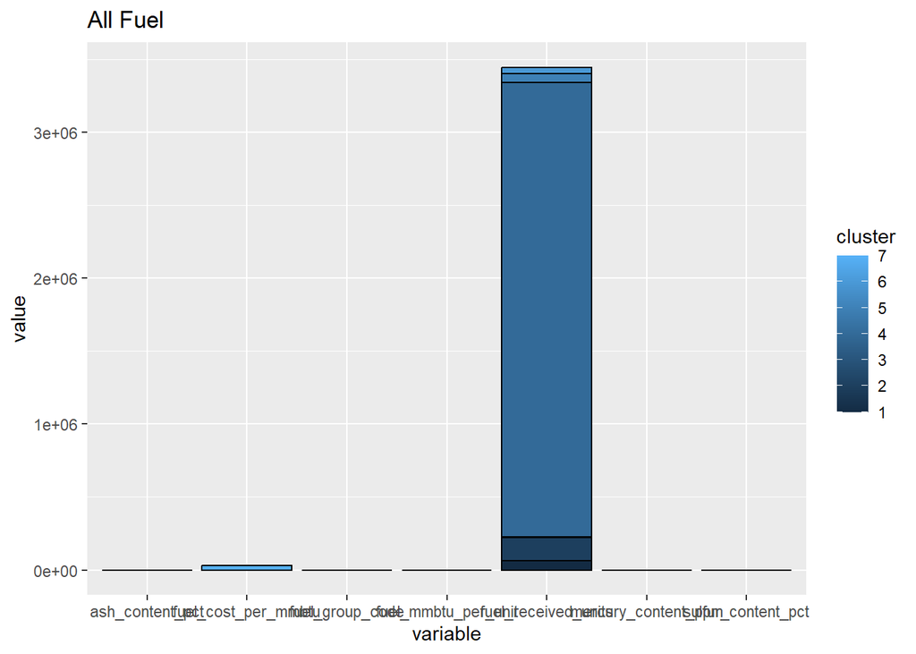

```r
all_fuel <- centers[, c(1:8)] %>% pivot_longer(col = !cluster, names_to = "variable", values_to = "value")

ggplot(data = all_fuel, aes(x = variable, y = value, fill = cluster)) + geom_col(colour = "black") + ggtitle("All Fuel")
```

## FUEL GROUP (TYPE)

### Normalizing data makes fuel group chart difficult to interpret, use center data above for type of fuel.

### Size of bar height is indicator of type (shorter is coal, tallest is petroleum).

### Categorical data converted for clustering.

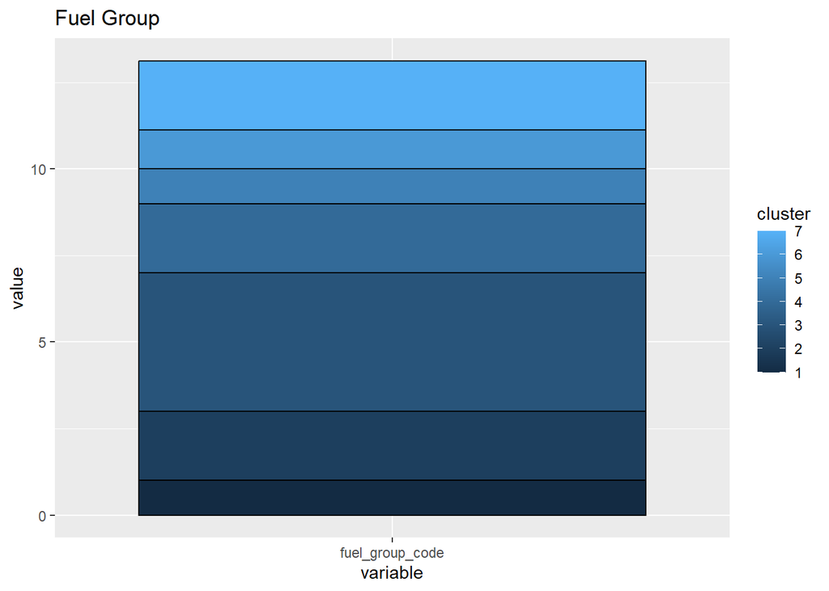

```r
fuel.group.plot <- centers[, c(1,2)] %>% pivot_longer(col = !cluster, names_to = "variable", values_to = "value")

ggplot(data = fuel.group.plot, aes(x = variable, y = value, fill = cluster)) + geom_col(colour = "black") + ggtitle("Fuel Group")
```

## FUEL RECEIVED UNITS

### Visual of how Standard Natural Gas predominates sample

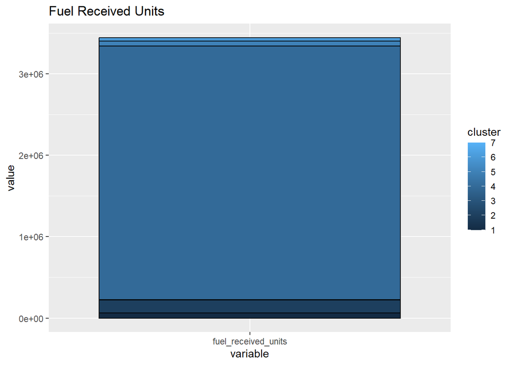

```r
fuel.received.units <- centers[, c(1,3)] %>% pivot_longer(col = !cluster, names_to = "variable", values_to = "value")

ggplot(data = fuel.received.units, aes(x = variable, y = value, fill = cluster)) + geom_col(colour = "black") + ggtitle("Fuel Received Units")
```

## FUEL MMBTU PER UNIT

### Clusters 1, 5 , 6 make the most heat per unit (all coal)

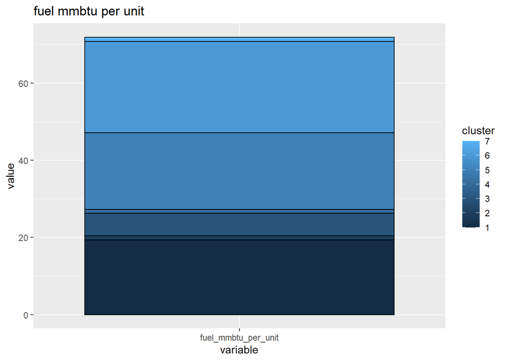

```r
fuel.mmbtu.per.unit <- centers[, c(1,4)] %>% pivot_longer(col = !cluster, names_to = "variable", values_to = "value")
ggplot(data = fuel.mmbtu.per.unit, aes(x = variable, y = value, fill = cluster)) + geom_col(colour = "black") + ggtitle("fuel mmbtu per unit")
```

## Sulfur Content

### The clusters with scant to no sulfur are hard to see on bar chart.

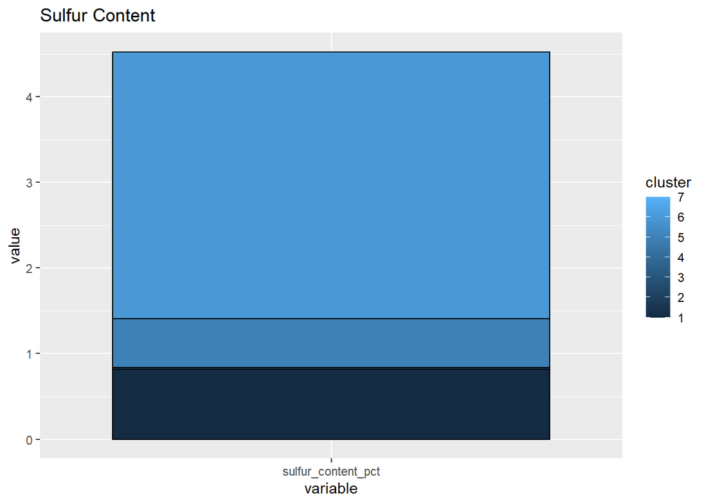

```r
sulfur.content.pct <- centers[, c(1,5)] %>% pivot_longer(col = !cluster, names_to = "variable", values_to = "value")

ggplot(data = sulfur.content.pct, aes(x = variable, y = value, fill = cluster)) + geom_col(colour = "black") + ggtitle("Sulfur Content")
```

## Ash Content

### Same as Sulfur, the natural gas clusters aren’t visible.

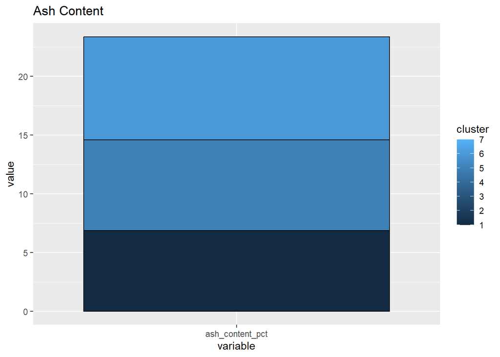

```r
ash.content <- centers[, c(1,6)] %>% pivot_longer(col = !cluster, names_to = "variable", values_to = "value")

ggplot(data = ash.content , aes(x = variable, y = value, fill = cluster)) + geom_col(colour = "black") + ggtitle("Ash Content")
```

## Mercury Content

### Predominately one cluster

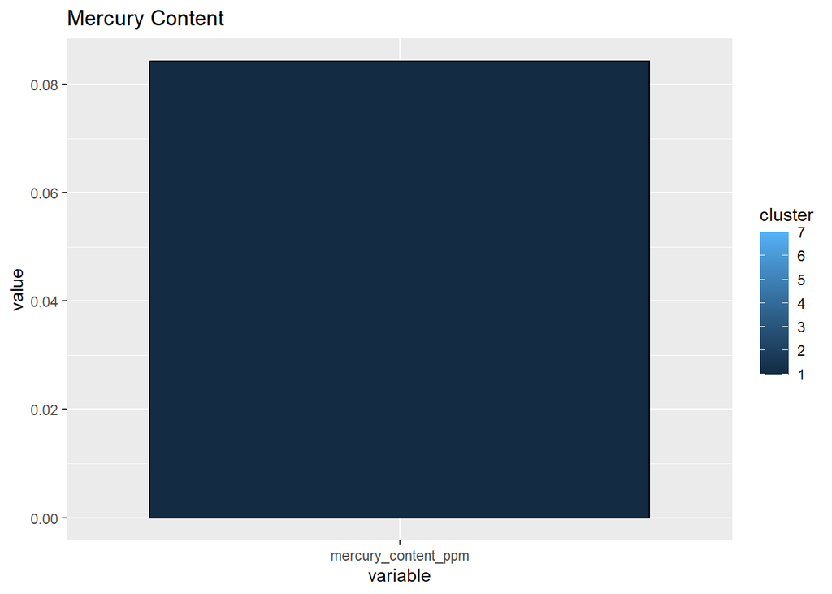

```r
mercury.content <- centers[, c(1,7)] %>% pivot_longer(col = !cluster, names_to = "variable", values_to = "value")

ggplot(data = mercury.content , aes(x = variable, y = value, fill = cluster)) + geom_col(colour = "black") + ggtitle("Mercury Content")
```

## Fuel Cost Per MMBTU

### One type of natural gas was extremely expensive and skewed data

### use center data above for costs.

### Suspect there may be a special purpose natural gas that must be ultra clean.

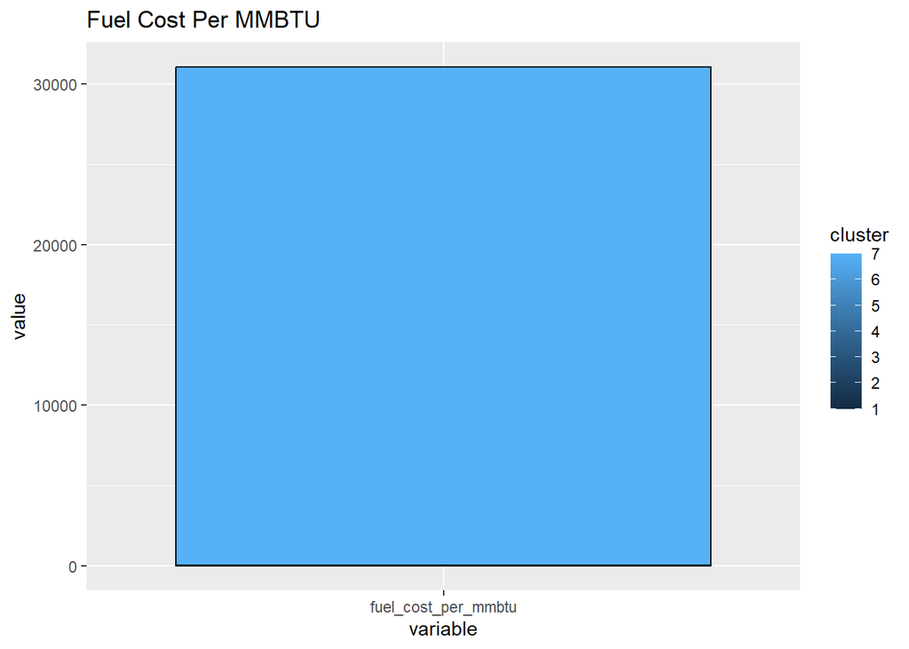

```r
fuel.cost.per.mmbtu <- centers[, c(1,8)] %>% pivot_longer(col = !cluster, names_to = "variable", values_to = "value")

ggplot(data = fuel.cost.per.mmbtu, aes(x = variable, y = value, fill = cluster)) + geom_col(colour = "black") + ggtitle("Fuel Cost Per MMBTU")
```

## To improve report ### Possible further conversion of categorical data (transportation type). ### Ensure Cost per unit is complete and accurate. ### Eliminate blank and N/A in important columns. If none/Scant, put zero.